# Case Study - Bank Marketing

Ming Ming Zhang

## Abstract

This case study uses the [data](https://archive.ics.uci.edu/ml/datasets/Bank+Marketing) that includes direct marketing campaigns (i.e., phone calls) of a Portuguese banking institution. The goal is to predict if the client will subscribe a term deposit (indicated in the variable `y`).

The dataset contains $41,188$ examples, $20$ features and a response variable labled by `y`, ordered by date (from May 2008 to November 2010). Since the dataset is imbalanced (about $11\%$ subscribe rate), the $F_1$ score will be used throughout this case study. The similar dataset was analyzed in [Moro et al., 2014](http://dx.doi.org/10.1016/j.dss.2014.03.001) where they implemented and used the package `rminer` of the `R` tool.

In this work, we test four binary classificaition models, using the packages `rminer`, `rpart` and `nnet` from `R` and the package `nn_model_np` of `Python` implemented by the author: decision tree (`R`), logistic regression (`R`), $2$-layer neural network (`R`) and $3$-layer neural network (`Python`). By using a certain splitting ratio and more complex model $3$-layer neural network, we are able to improve the results in [Table 3, Moro et al., 2014](http://dx.doi.org/10.1016/j.dss.2014.03.001).

First, we analyze the data using the package `rminer` of `R`. By setting the holdout method with the splitting ratio $0.8/0.2$ repeated $20$ times, the results in [Table 3, Moro et al., 2014](http://dx.doi.org/10.1016/j.dss.2014.03.001) are improved in AUC metric (the 2nd column of the below table) for decision tree, logistic regression and single hidden layer neural network with $6$ units and $7$ ensembles (stated as “Neural Network” below). Recall that the best model in [Moro et al., 2014](http://dx.doi.org/10.1016/j.dss.2014.03.001) is a single hidden layer neural network with $6$ units, $7$ ensembles, splitting ratio $\frac{2}{3}/\frac{1}{3}$ repeated $20$ times, with the performance of $0.929$ AUC metric.

```r
df_res1
```

|  | F1 | AUC | ALIFT |
| --- | --- | --- | --- |
| Decision Tree | 0.5687019 | 0.8580987 | 0.7780156 |
| Logistic Regression | 0.5128668 | 0.9338263 | 0.8849116 |
| Neural Network | 0.5914690 | 0.9376071 | 0.8881304 |

Next, we improve the results even further. We divide the data into training, development and test set with ratio $0.8$, $0.1$ and $0.1$, respectively, and train the data using decision tree, logistic regression, single and multi-hidden layer neural networks (stated as “2-Layer Neural Network” and “3-Layer Neural Network” below). The results preformed on the development set are summarized in the following table (the columns are precision, recall and $F_1$ score, respectively).

```r
df_res
```

|  | precision | recall | F1 |
| --- | --- | --- | --- |
| Decision Tree | 0.6351351 | 0.5032120 | 0.5615293 |
| Logistic Regression | 0.6877076 | 0.4312500 | 0.5300896 |
| 2-Layer Neural Network | 0.6205387 | 0.5187500 | 0.5619603 |
| 3-Layer Neural Network | 0.5702746 | 0.7354167 | 0.6424022 |

The best model “3-Layer Neural Network”, as implemented in the package `nn_model_np` of the `Python` tool, is an $2$-hidden layer neural network with $5$ and $2$ units, respectively, with ReLu-ReLu-Sigmoid activation functions and momentum gradient descent optimizer ($0.3$ learning rate, $0.9$ moving average rate, $32$ mini-batch size and $500$ epochs). The `Python` code can be found in [here](https://github.com/DrMMZ/drmmz.github.io/blob/master/bank.ipynb). On the other hand, the package `rpart` of `R` is applied to “Decision Tree” and the package `nnet` of `R` is used in “Logistic Regression” and “2-Layer Neural Network”, which is a single hidden layer neural network with $6$ units and $7$ ensembles.

Comparing to the best performance of [Table 3, Moro et al., 2014](http://dx.doi.org/10.1016/j.dss.2014.03.001) $F_1$ score $0.5914690$, our best result is given by “3-Layer Neural Network” on the test set $F_1$ score $0.6386093$ with improvement of about $4.7\%$. The performance is summarized as follow.

```r
df_finalRes
```

|  | precision | recall | F1 |
| --- | --- | --- | --- |
| 3-Layer Neural Network | 0.5711948 | 0.7240664 | 0.6386093 |

By using the “Decision Tree” and “Logistic Regression” models, we obtain the two lists of ranking features.

```r
names(dt_impVars)
```

```
 [1] "duration"       "nr.employed"    "euribor3m"      "emp.var.rate"   "cons.conf.idx"  "cons.price.idx" "month"
 [8] "pdays"          "poutcome"       "previous"       "campaign"       "job"            "age"            "education"
[15] "marital"
```

```r
names(lr_impVars)
```

```
 [1] "emp.var.rate"                 "monthmar"                     "cons.price.idx"               "duration"
 [5] "educationilliterate"          "euribor3m"                    "poutcomesuccess"              "monthaug"
 [9] "contacttelephone"             "monthnov"                     "monthjun"                     "defaultyes"
[13] "monthmay"                     "poutcomenonexistent"          "monthsep"                     "jobstudent"
[17] "defaultunknown"               "jobself-employed"             "jobretired"                   "day_of_weekwed"
[21] "educationuniversity.degree"   "pdays"                        "loanunknown"                  "monthdec"
[25] "nr.employed"                  "educationbasic.6y"            "educationunknown"             "jobmanagement"
[29] "jobblue-collar"               "day_of_weektue"               "educationprofessional.course" "jobunemployed"
[33] "monthjul"                     "cons.conf.idx"                "housingunknown"               "campaign"
[37] "educationhigh.school"         "day_of_weekthu"               "maritalunknown"               "jobunknown"
[41] "jobservices"                  "maritalsingle"                "jobentrepreneur"              "day_of_weekmon"
[45] "jobhousemaid"                 "loanyes"                      "age"                          "previous"
[49] "monthoct"                     "educationbasic.9y"            "jobtechnician"                "housingyes"
[53] "maritalmarried"
```

## 1. Packages

```r
source("~/Downloads/bank-additional/evaluation.R")
library(rminer)
library(rpart)
library(nnet)
```

## 2. The Data

```r
D = read.table("bank-additional-full.csv", header=TRUE, sep=";")
str(D)
```

```
'data.frame':   41188 obs. of  21 variables:
 $ age           : int  56 57 37 40 56 45 59 41 24 25 ...
 $ job           : Factor w/ 12 levels "admin.","blue-collar",..: 4 8 8 1 8 8 1 2 10 8 ...
 $ marital       : Factor w/ 4 levels "divorced","married",..: 2 2 2 2 2 2 2 2 3 3 ...
 $ education     : Factor w/ 8 levels "basic.4y","basic.6y",..: 1 4 4 2 4 3 6 8 6 4 ...
 $ default       : Factor w/ 3 levels "no","unknown",..: 1 2 1 1 1 2 1 2 1 1 ...
 $ housing       : Factor w/ 3 levels "no","unknown",..: 1 1 3 1 1 1 1 1 3 3 ...
 $ loan          : Factor w/ 3 levels "no","unknown",..: 1 1 1 1 3 1 1 1 1 1 ...
 $ contact       : Factor w/ 2 levels "cellular","telephone": 2 2 2 2 2 2 2 2 2 2 ...
 $ month         : Factor w/ 10 levels "apr","aug","dec",..: 7 7 7 7 7 7 7 7 7 7 ...
 $ day_of_week   : Factor w/ 5 levels "fri","mon","thu",..: 2 2 2 2 2 2 2 2 2 2 ...
 $ duration      : int  261 149 226 151 307 198 139 217 380 50 ...
 $ campaign      : int  1 1 1 1 1 1 1 1 1 1 ...
 $ pdays         : int  999 999 999 999 999 999 999 999 999 999 ...
 $ previous      : int  0 0 0 0 0 0 0 0 0 0 ...
 $ poutcome      : Factor w/ 3 levels "failure","nonexistent",..: 2 2 2 2 2 2 2 2 2 2 ...
 $ emp.var.rate  : num  1.1 1.1 1.1 1.1 1.1 1.1 1.1 1.1 1.1 1.1 ...
 $ cons.price.idx: num  94 94 94 94 94 ...
 $ cons.conf.idx : num  -36.4 -36.4 -36.4 -36.4 -36.4 -36.4 -36.4 -36.4 -36.4 -36.4 ...
 $ euribor3m     : num  4.86 4.86 4.86 4.86 4.86 ...
 $ nr.employed   : num  5191 5191 5191 5191 5191 ...
 $ y             : Factor w/ 2 levels "no","yes": 1 1 1 1 1 1 1 1 1 1 ...
```

### 2.1. Normalization

```r
normalizedD = D

intL = c()
for (x in names(D)) {
  if (class(D[,x])=="integer" | class(D[,x])=="numeric") {
    normalizedD[,x] = (D[,x] - mean(D[,x])) / sd(D[,x])
    intL = c(intL, x, mean(D[,x]), sd(D[,x]))
  }
}
#intL
str(normalizedD)
```

```
'data.frame':   41188 obs. of  21 variables:
 $ age           : num  1.53302 1.62897 -0.29018 -0.00231 1.53302 ...
 $ job           : Factor w/ 12 levels "admin.","blue-collar",..: 4 8 8 1 8 8 1 2 10 8 ...
 $ marital       : Factor w/ 4 levels "divorced","married",..: 2 2 2 2 2 2 2 2 3 3 ...
 $ education     : Factor w/ 8 levels "basic.4y","basic.6y",..: 1 4 4 2 4 3 6 8 6 4 ...
 $ default       : Factor w/ 3 levels "no","unknown",..: 1 2 1 1 1 2 1 2 1 1 ...
 $ housing       : Factor w/ 3 levels "no","unknown",..: 1 1 3 1 1 1 1 1 3 3 ...
 $ loan          : Factor w/ 3 levels "no","unknown",..: 1 1 1 1 3 1 1 1 1 1 ...
 $ contact       : Factor w/ 2 levels "cellular","telephone": 2 2 2 2 2 2 2 2 2 2 ...
 $ month         : Factor w/ 10 levels "apr","aug","dec",..: 7 7 7 7 7 7 7 7 7 7 ...
 $ day_of_week   : Factor w/ 5 levels "fri","mon","thu",..: 2 2 2 2 2 2 2 2 2 2 ...
 $ duration      : num  0.0105 -0.4215 -0.1245 -0.4138 0.1879 ...
 $ campaign      : num  -0.566 -0.566 -0.566 -0.566 -0.566 ...
 $ pdays         : num  0.195 0.195 0.195 0.195 0.195 ...
 $ previous      : num  -0.349 -0.349 -0.349 -0.349 -0.349 ...
 $ poutcome      : Factor w/ 3 levels "failure","nonexistent",..: 2 2 2 2 2 2 2 2 2 2 ...
 $ emp.var.rate  : num  0.648 0.648 0.648 0.648 0.648 ...
 $ cons.price.idx: num  0.723 0.723 0.723 0.723 0.723 ...
 $ cons.conf.idx : num  0.886 0.886 0.886 0.886 0.886 ...
 $ euribor3m     : num  0.712 0.712 0.712 0.712 0.712 ...
 $ nr.employed   : num  0.332 0.332 0.332 0.332 0.332 ...
 $ y             : Factor w/ 2 levels "no","yes": 1 1 1 1 1 1 1 1 1 1 ...
```

## 3. Evaluation

### 3.1. Metric

Since the response variable `y` is imbalanced, the metric $F_1$ score will be used.

```r
paste("Subscribers ratio:", table(D$y)[2] / sum(table(D$y)) )
```

```
[1] "Subscribers ratio: 0.112654171117801"
```

### 3.2. Train/Dev/Test

Since the dataset has large number of examples and the splitting ratio $0.9/0.05/0.05$ shows high variance between dev and test set, the ratio $0.8/0.1/0.1$ for splitting training/dev/test will be used.

```r
set.seed(1)

D1 = splitData(D)
normalizedD1 = splitData(normalizedD)

XY_train = D1[[1]]
XY_dev = D1[[2]]
XY_test = D1[[3]]

nXY_train = normalizedD1[[1]]
nXY_dev = normalizedD1[[2]]
nXY_test = normalizedD1[[3]]
```

Note that both dev and test set do not contain `default` example.

```r
table(XY_train$default)
```

```
     no unknown     yes
  26057    6890       3
```

```r
table(XY_dev$default)
```

```
     no unknown     yes
   3303     816       0
```

```r
table(XY_test$default)
```

```
     no unknown     yes
   3228     891       0
```

## 4. Modeling by `rminer`

It uses the same modeling architecture as in the paper from the library `rminer`, except the splitting ratio. More precisely, one uses the holdout method with $0.8/0.2$ splitting ratio repeated 20 times.

### 4.1. Decision Tree

```r
dt1 = mining(y~., D, method=c("holdout", 0.8), model="dt", Runs=20)

res_dt1 = mmetric(dt1, metric = c("F1", "AUC", "ALIFT"))
df_dt1 = data.frame("F1"=mean(res_dt1[,2])/100, "AUC"=mean(res_dt1[,3]), "ALIFT"=mean(res_dt1[,4]))
row.names(df_dt1) = "Decision Tree"
df_dt1
```

|  | F1 | AUC | ALIFT |
| --- | --- | --- | --- |
| Decision Tree | 0.5687019 | 0.8580987 | 0.7780156 |

```r
#mgraph(dt1, graph="ROC", Grid=10, baseline=TRUE)
```

### 4.2. Logistic Regression

```r
lr1 = mining(y~., normalizedD, method=c("holdout", 0.8), model="lr", Runs=20)

res_lr1 = mmetric(lr1, metric = c("F1", "AUC", "ALIFT"))
df_lr1 = data.frame("F1"=mean(res_lr1[,2])/100, "AUC"=mean(res_lr1[,3]), "ALIFT"=mean(res_lr1[,4]))
row.names(df_lr1) = "Logistic Regression"
df_lr1
```

|  | F1 | AUC | ALIFT |
| --- | --- | --- | --- |
| Logistic Regression | 0.5128668 | 0.9338263 | 0.8849116 |

```r
#mgraph(lr1, graph="ROC", Grid=10, baseline=TRUE)
```

### 4.3. Neural Network

The next neural network has 1 hidden layer with 6 nodes repeated 7 times.

```r
nn1 = mining(y~., normalizedD, method=c("holdout", 0.8), model="mlp", size = 6, nr = 7, maxit = 1000, Runs=20)

res_nn1 = mmetric(nn1, metric = c("F1", "AUC", "ALIFT"))
df_nn1 = data.frame("F1"=mean(res_nn1[,2])/100, "AUC"=mean(res_nn1[,3]), "ALIFT"=mean(res_nn1[,4]))
row.names(df_nn1) = "Neural Network"
df_nn1
```

|  | F1 | AUC | ALIFT |
| --- | --- | --- | --- |
| Neural Network | 0.591469 | 0.9376071 | 0.8881304 |

```r
#mgraph(nn1, graph="ROC", Grid=10, baseline=TRUE)
```

### 4.4. Results

```r
df_res1 = rbind.data.frame(df_dt1, df_lr1, df_nn1)
df_res1
```

|  | F1 | AUC | ALIFT |
| --- | --- | --- | --- |
| Decision Tree | 0.5687019 | 0.8580987 | 0.7780156 |
| Logistic Regression | 0.5128668 | 0.9338263 | 0.8849116 |
| Neural Network | 0.5914690 | 0.9376071 | 0.8881304 |

## 5. Modeling

### 5.1. Decision Tree

```r
start.time = Sys.time()
dt = rpart(y~., data = XY_train)
end.time = Sys.time()
time.taken = end.time - start.time
time.taken
```

```
Time difference of 1.135114 secs
```

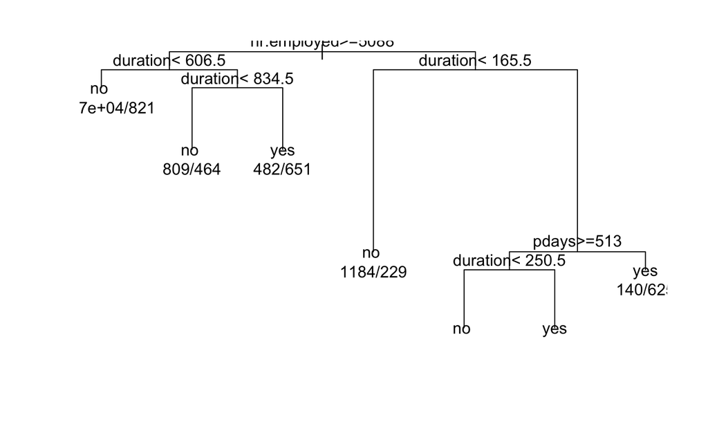

```r
plot(dt)
text(dt, use.n = TRUE)
```

```r
pdev_dt = predict(dt, newdata = XY_dev, type = "vector") - 1
df_dt = data.frame(F1(as.numeric(XY_dev$y) - 1, pdev_dt))
row.names(df_dt) = "Decision Tree"
df_dt
```

|  | precision | recall | F1 |
| --- | --- | --- | --- |
| Decision Tree | 0.6351351 | 0.503212 | 0.5615293 |

### 5.2. Logistic Regression

```r
start.time = Sys.time()
lr = nnet(as.numeric(y)-1~., data = nXY_train, size = 0, skip = T, entropy = T, maxit = 1000)
end.time = Sys.time()
time.taken = end.time - start.time
time.taken
```

```
Time difference of 3.060606 secs
```

```r
pdev_lr = predict(lr, newdata = nXY_dev)
pdev_lr = ifelse(pdev_lr>0.5, 1, 0)
df_lr = data.frame(F1(as.numeric(nXY_dev$y) - 1, pdev_lr))
row.names(df_lr) = "Logistic Regression"
df_lr
```

|  | precision | recall | F1 |
| --- | --- | --- | --- |
| Logistic Regression | 0.6877076 | 0.43125 | 0.5300896 |

### 5.3. Neural Networks

#### 5.3.1. 1-Hidden Layer

The next neural network is used by the library `nnet`, which has 1 hidden layer with 6 nodes repeated 7 times.

```r
start.time = Sys.time()

m = 7
mat_nns = matrix(0, nrow = m, ncol = 3)
colnames(mat_nns) = c("precision", "recall", "F1")
for (i in 1:m) {
  nn = nnet(as.numeric(y)-1~., data = nXY_train, size = 6, entropy = T, maxit = 1000, trace = F)
  pdev_nn = predict(nn, newdata = nXY_dev)
  pdev_nn = ifelse(pdev_nn>0.5, 1, 0)
  mat_nns[i,] = unlist(F1(as.numeric(nXY_dev$y) - 1, pdev_nn))
}
mat_nns
```

```
     precision    recall        F1
[1,] 0.6531250 0.4354167 0.5225000
[2,] 0.6215596 0.5645833 0.5917031
[3,] 0.6725146 0.4791667 0.5596107
[4,] 0.6100000 0.5083333 0.5545455
[5,] 0.6158038 0.4708333 0.5336482
[6,] 0.5923567 0.5812500 0.5867508
[7,] 0.5784114 0.5916667 0.5849640
```

```r
end.time = Sys.time()
time.taken = end.time - start.time
time.taken
```

```
Time difference of 4.447728 mins
```

```r
df_nn_1 = data.frame("precision"=mean(mat_nns[,1]), "recall"=mean(mat_nns[,2]), "F1"=mean(mat_nns[,3]))
row.names(df_nn_1) = "2-Layer Neural Network"
df_nn_1
```

|  | precision | recall | F1 |
| --- | --- | --- | --- |
| 2-Layer Neural Network | 0.6205387 | 0.51875 | 0.5619603 |

#### 5.3.2. 2-Hidden Layer

We use the program implemented in `Python` to train another neural network. Code can be found in [here](https://github.com/DrMMZ/drmmz.github.io/blob/master/bank.ipynb).

First, we need to convert the data in the format used in the program.

```r
library(caret)

dmy = dummyVars(" ~ .", data = nXY_train[, names(nXY_train)!="y"], fullRank = T)
X_train = data.frame(predict(dmy, newdata = nXY_train[, names(nXY_train)!="y"]))
Y_train = nXY_train[, names(nXY_train)=="y"]
Y_train = as.numeric(Y_train) - 1

dmy = dummyVars(" ~ .", data = nXY_dev[, names(nXY_dev)!="y"], fullRank = T)
X_dev = data.frame(predict(dmy, newdata = nXY_dev[, names(nXY_dev)!="y"]))
Y_dev = nXY_dev[, names(nXY_dev)=="y"]
Y_dev = as.numeric(Y_dev) - 1

dmy = dummyVars(" ~ .", data = nXY_test[, names(nXY_test)!="y"], fullRank = T)
X_test = data.frame(predict(dmy, newdata = nXY_test[, names(nXY_test)!="y"]))
Y_test = nXY_test[, names(nXY_test)=="y"]
Y_test = as.numeric(Y_test) - 1
```

After anaylzing in `Python`’s program, we obtain an 2-hidden layer (or 3-layer) neural network; in particular, 5 and 2 units in the 1st and 2nd hidden layer, respectively, ReLu-ReLu-Sigmoid activation functions and gradient descent with momentum optimizer (0.3 learning rate and 500 epochs). The performance on the dev set is shown below.

```r
df_nn_2 = data.frame("precision"=0.5702746, "recall"=0.7354167, "F1"=0.6424022)
row.names(df_nn_2) = "3-Layer Neural Network"
df_nn_2
```

|  | precision | recall | F1 |
| --- | --- | --- | --- |
| 3-Layer Neural Network | 0.5702746 | 0.7354167 | 0.6424022 |

### 5.4. Results

```r
df_res = rbind.data.frame(df_dt, df_lr, df_nn_1, df_nn_2)
df_res
```

|  | precision | recall | F1 |
| --- | --- | --- | --- |
| Decision Tree | 0.6351351 | 0.5032120 | 0.5615293 |
| Logistic Regression | 0.6877076 | 0.4312500 | 0.5300896 |
| 2-Layer Neural Network | 0.6205387 | 0.5187500 | 0.5619603 |
| 3-Layer Neural Network | 0.5702746 | 0.7354167 | 0.6424022 |

From the previous table, we select 3-Layer Neural Network as the final model. The performance on the test set is the following.

```r
df_finalRes = data.frame("precision"=0.5711948, "recall"=0.7240664, "F1"=0.6386093)
row.names(df_finalRes) = "3-Layer Neural Network"
df_finalRes
```

|  | precision | recall | F1 |
| --- | --- | --- | --- |
| 3-Layer Neural Network | 0.5711948 | 0.7240664 | 0.6386093 |

## 6. Important Features

From the decision tree using `rpart`, we can rank the importance of the features.

```r
dt_impVars = dt$variable.importance
names(dt_impVars)
```

```
 [1] "duration"       "nr.employed"    "euribor3m"      "emp.var.rate"   "cons.conf.idx"  "cons.price.idx" "month"
 [8] "pdays"          "poutcome"       "previous"       "campaign"       "job"            "age"            "education"
[15] "marital"
```

Moreover, we can obtain another ordered list of important features based on logistic regression using `nnet`.

```r
wts = lr$wts
wts = wts[2:54]
names(wts) = lr$coefnames
lr_impVars = sort(abs(wts), decreasing = T)
names(lr_impVars)
```

```
 [1] "emp.var.rate"                 "monthmar"                     "cons.price.idx"               "duration"
 [5] "educationilliterate"          "euribor3m"                    "poutcomesuccess"              "monthaug"
 [9] "contacttelephone"             "monthnov"                     "monthjun"                     "defaultyes"
[13] "monthmay"                     "poutcomenonexistent"          "monthsep"                     "jobstudent"
[17] "defaultunknown"               "jobself-employed"             "jobretired"                   "day_of_weekwed"
[21] "educationuniversity.degree"   "pdays"                        "loanunknown"                  "monthdec"
[25] "nr.employed"                  "educationbasic.6y"            "educationunknown"             "jobmanagement"
[29] "jobblue-collar"               "day_of_weektue"               "educationprofessional.course" "jobunemployed"
[33] "monthjul"                     "cons.conf.idx"                "housingunknown"               "campaign"
[37] "educationhigh.school"         "day_of_weekthu"               "maritalunknown"               "jobunknown"
[41] "jobservices"                  "maritalsingle"                "jobentrepreneur"              "day_of_weekmon"
[45] "jobhousemaid"                 "loanyes"                      "age"                          "previous"
[49] "monthoct"                     "educationbasic.9y"            "jobtechnician"                "housingyes"
[53] "maritalmarried"
```